# NVD Report

Mohamad El Iskandarani

**Summer 2022 | Darden School of Business | University of Virginia**

# Introduction

The following is a summary report of the data analysis performed on NIST’s National Vulnerability Database (NVD) as part of a research internship during Summer 2022. The findings were recorded progressively based on the bi-weekly meetings with Prof. Vidya Mani (https://www.darden.virginia.edu/faculty-research/directory/vidya-mani). Each time section is concluded with a **Key Takeaways** section which summarizes the main points derived throughout the analysis.

# May 20th - June 9th

The first step is to find the most occurring CWE, its parent, and its children. We stop traceback when we arrive at the pillar, and only 1 layer of children are considered so far. The CWE tree can be found at cwe.mitre.org. CWE-79 is the most occurring CWE over the years 2021 (and 2019,2020,2021 as well). Almost 20% of the data has no CWE tag. CWE-79 is the CHILD of CWE-74, and CWE-79 is the child of the pillar CWE-707. CWE-79 is the PARENT of CWE-80 , 81, 83, 84, 85, 87, and 692.

| CWE | n | p |
| --- | --- | --- |
| No info | 10949 | 19.587112 |
| CWE-79 | 6401 | 11.451010 |
| CWE-787 | 4038 | 7.223743 |

Now that we understand the CWE sub-tree, we can do some plots.

## Finding The Most Frequent CWE

**Q: Can we visually detect any trend for the top CWE sub tree in 2021?**

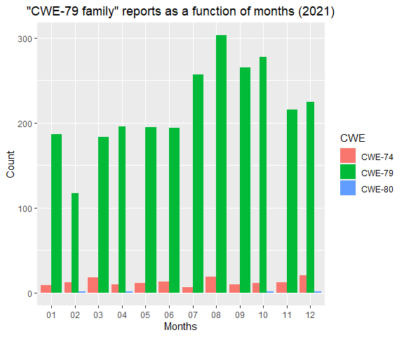

We cannot visually detect any consistent trend throughout 2021. This motivates us to include previous years and increase the dataset size.

## Exploring CWE Trends

**Q: Is there a trend to the number of CWE-79 reports as a function of years?**

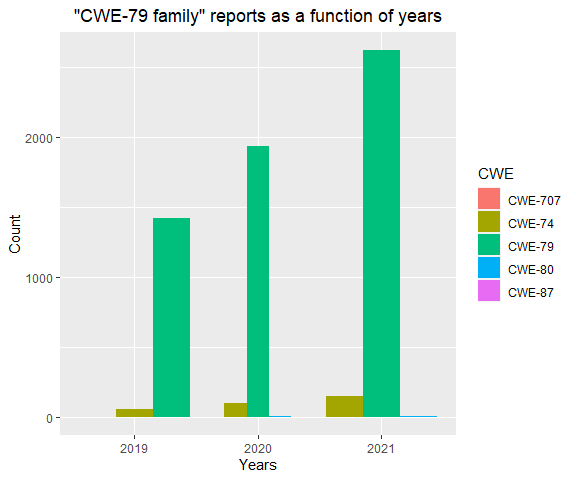

Looking at years 2019 - 2021, we can notice that the number of CWE-79 reports is increasing. However, this could be solely due to increased reporting throughout the years. Thus, we have to look at percentages.

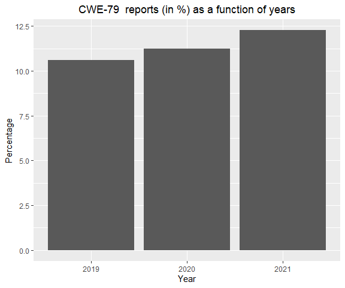

As seen in the bar plot, the percentage of CWe-79 reports is indeed increasing.Next, we explore the severity levels of CWE-79. Recall that there are four BaseSeverity levels: LOW, MEDIUM, HIGH, and CRITICAL.

## Exploring BaseSeverity Trends

**Q: Can we detect a trend in BaseSeverity levels as a function of years?**

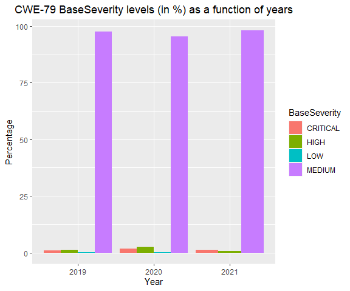

Looking at the severities of the CWE-79 report percentages, we cannot detect any consistent trend. However, we can clearly see that MEDIUM BaseSeverity composes the majority of the CWE-79 reports.

## Exploring Vendor Trends

Our definition of vendor is the party which **assigned** the vulnerability metadata. As such, a vulnerability assigned by Mitre (the team behind the CWE) could be about a Microsoft service or Cisco product. The distinction is made clearer in the following time sections.

**Q: Which vendor is the most prevalent?**

| Vendor | n | p | PublishedYear |
| --- | --- | --- | --- |
| Mitre | 5884 | 43.999103 | 2019 |
| Mitre | 6459 | 37.539231 | 2020 |
| Mitre | 7843 | 36.773256 | 2021 |
| Microsoft | 1262 | 7.334651 | 2020 |
| Microsoft | 844 | 6.311224 | 2019 |

Mitre is the most prevalent vendor type, which is the team behind the CWE. In other words, almost half of the vulnerabilities were not reported by the vendors themselves. Other than Mitre, it seems that Microsoft is the most prevalent vendor in 2020 and 2019, and the second most in 2021.

**Q: What are the most occuring CWE types within the Microsoft reports?**

| CWE | n | p | PublishedYear |
| --- | --- | --- | --- |
| No info | 938 | 74.326466 | 2020 |
| No info | 523 | 60.045924 | 2021 |
| No info | 350 | 41.469194 | 2019 |
| CWE-269 | 182 | 20.895522 | 2021 |
| CWE-787 | 148 | 17.535545 | 2019 |
| CWE-200 | 83 | 9.834123 | 2019 |
| CWE-787 | 87 | 6.893819 | 2020 |

41%, 74%, and 60% of Microsoft’s reports for years 2019, 2020, 2021 respectively are of NO INFO. Year 2019: CWE-787 (17.5%). Year 2020: CWE-787 (6.8%). Year 2021: CWE-269 (21%).Note that CWE-79, the most occuring CWE type across the NVD database by a large margin, wasn’t the top CWE type within the most occuring categorized vendor. This could indicate that either the Mitre reports are mainly CWE-79, or CWE-79 is spread across a lot of vendors.

**Q: What are the most occuring CWE types within the Mitre reports?**

| CWE | n | p | PublishedYear |
| --- | --- | --- | --- |
| No info | 1849 | 23.57516 | 2021 |
| No info | 1205 | 18.65614 | 2020 |
| No info | 1067 | 18.13392 | 2019 |
| CWE-79 | 1106 | 17.12339 | 2020 |
| CWE-79 | 1195 | 15.23652 | 2021 |
| CWE-79 | 870 | 14.78586 | 2019 |

As expected, no info is the most occurring type across all years. Confirming the first hypothesis above, CWE-79 is the most occuring type within Mitre reports for all years 2019, 2020, and 2021.

## Key Takeaways

1. Roughly 20% of the reports don’t have CWE tags, which is problematic for data analysis.
2. Due to the relatively low report numbers by vendors (like Microsoft or Cisco), we will focus on reports by Mitre.
3. We will restrict our focus to CWE-79 reports by Mitre (at least for the upcoming time section).

# June 10th - June 23rd

## Mitre CWE-79 Reports

Between years 2019 - 2021, we have 3,171 CWE-79 reports by Mitre, which composes 53.1% of the total CWE-79 reports. This indicates that 0.28% of the total vendors (1 out of 356) has reported 53.1% of the most occurring CWE tag.

First, it is useful to understand what the CWE-79 vulnerability is. Looking at https://cwe.mitre.org/data/definitions/79.html, we find the following:

1. By definition, CWE-79 is the improper neutralization of user input before it is placed on the webpage output for other users to use. In laymen terms, I can inject a malicious script that stores passwords from the “Login page” of a website, and other users using this website fall victim to my injection. Ideally, the webpage itself should not allow one user to store private information about another user.
2. Thus, it makes sense that Mitre is reporting the majority of this vulnerability since it is webpage-based. However, we cannot be sure of this conclusion until we analyze the descriptions and reference links of the CWE-79 reports. Analyzing the description text and reference allows us to see if the categorization is accurate and if the reports are really from standalone websites, or if Mitre is reporting on the behalf of companies and vendors.

**Q: Are the CWE tags accurate?**

By that we mean: “could the description provide information such that the CWE tag be a child of CWE-79 rather than CWE-79?”. Accurate CWE tags are crucial for developing patches in a timely fashion. An alternate direction would be to analyze the description text of No-info tags to see if they in fact could be tagged.

## NVD Temporal Analysis

**Q: What are the changes to the NVD JSON Datafeeds?**

We would like to know what exactly is changing in the previous year datafeeds that are constantly being updated. In addition to new reports, are already existing ones being revisited? Are NO-INFO CWE tags being updated for instance?

To do that, we downloaded the most recent version of the 2020 database on four days (June 10th, June 13th, June 16th, June 20th). Next, we read the databases and find the differences between them.  
Looking at the entry numbers, no new entry was added throughout this span. One cannot make the assumption that new entries are never added, for a lengthier temporal analysis is required. An example output (June 10th vs June 20th) was included in the report to show the types of differences. Green indicates the edited row in the newer dataset, while red indicates the original one.

| rowname | chng_type | CVE-ID | Vendor | CWE | CVSS | BaseScore | BaseSeverity | ExploitabilityScore | ImpactScore | PublishedYear | PublishedMonth | PublishedDay | Description | Reference_Link |
| --- | --- | --- | --- | --- | --- | --- | --- | --- | --- | --- | --- | --- | --- | --- |
| 10321 | + | CVE-2020-4008 | Vmware | No info | 3.1 | 7.1 | HIGH | 1.8 | 5.2 | 2020 | 12 | 16 | The installer of the macOS Sensor for VMware Carbon Black Cloud (prior to 3.5.1) handles certain files in an insecure way. A malicious actor who has local access to the endpoint on which a macOS senso… | https://www.vmware.com/security/advisories/VMSA-2020-0028.html |
| 10321 | - | CVE-2020-4008 | Vmware | No info | 3.1 | 3.6 | LOW | 1 | 2.5 | 2020 | 12 | 16 | The installer of the macOS Sensor for VMware Carbon Black Cloud (prior to 3.5.1) handles certain files in an insecure way. A malicious actor who has local access to the endpoint on which a macOS senso… | https://www.vmware.com/security/advisories/VMSA-2020-0028.html |
| 13034 | + | CVE-2020-8177 | Hackerone | CWE-74 | 3.1 | 7.1 | HIGH | 1.8 | 5.2 | 2020 | 12 | 14 | curl 7.20.0 through 7.70.0 is vulnerable to improper restriction of names for files and other resources that can lead too overwriting a local file when the -J flag is used. | https://curl.se/docs/CVE-2020-8177.html |
| 13034 | - | CVE-2020-8177 | Hackerone | CWE-74 | 3.1 | 7.8 | HIGH | 1.8 | 5.9 | 2020 | 12 | 14 | curl 7.20.0 through 7.70.0 is vulnerable to improper restriction of names for files and other resources that can lead too overwriting a local file when the -J flag is used. | https://curl.se/docs/CVE-2020-8177.html |
| 2119 | + | CVE-2020-11579 | Mitre | CWE-306 | 3.1 | 7.5 | HIGH | 3.9 | 3.6 | 2020 | 09 | 03 | An issue was discovered in Chadha PHPKB 9.0 Enterprise Edition. installer/test-connection.php (part of the installation process) allows a remote unauthenticated attacker to disclose local files on hos… | https://www.knowledgebase-script.com/ |
| 2119 | - | CVE-2020-11579 | Mitre | CWE-306 | 3.1 | 7.5 | HIGH | 3.9 | 3.6 | 2020 | 09 | 03 | An issue was discovered in Chadha PHPKB 9.0 Enterprise Edition. installer/test-connection.php (part of the installation process) allows a remote unauthenticated attacker to disclose local files on hos… | https://github.com/ShielderSec/CVE-2020-11579 |
| 8209 | + | CVE-2020-27068 | Android | CWE-125 | 3.1 | 4.4 | MEDIUM | 0.8 | 3.6 | 2020 | 12 | 15 | In the nl80211_policy policy of nl80211.c, there is a possible out of bounds read due to a missing bounds check. This could lead to local information disclosure with System execution privileges needed… | https://source.android.com/security/bulletin/pixel/2020-12-01 |
| 8209 | - | CVE-2020-27068 | Android | CWE-125 | 3.1 | 4.4 | MEDIUM | 0.8 | 3.6 | 2020 | 12 | 15 | Product: AndroidVersions: Android kernelAndroid ID: A-127973231References: Upstream kernel | https://source.android.com/security/bulletin/pixel/2022-06-01 |

**Q: How and why are scores changed?**

```
#> [1] "https://www.vmware.com/security/advisories/VMSA-2020-0028.html"
```

## Analyzing The Severe Reports

Our definition of “severe” is the reports that have a baseSeverity of either HIGH or CRITICAL.

**Q: What we can we uncover from the high and critical reports?**

Filtering the HIGH and CRITICAL reports, we find that they compose 54% of the NVD (2019 - 2021), where HIGH and CRITICAL constitute 40.5% and 13.5% respectively.

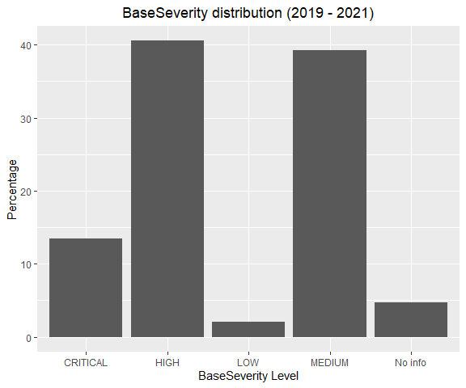

**Q: How are the BaseSeverity levels evolving as a function of years?**

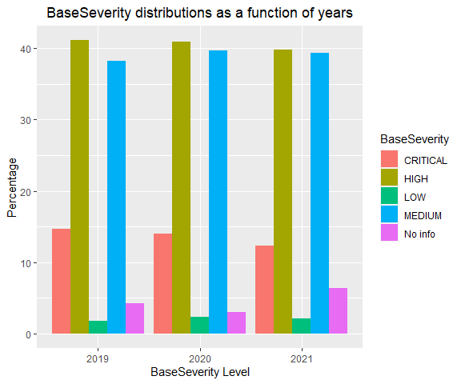

It seems that the BaseSeverity level distributions are very similar across the years.

## Key Takeaways

1. The NVD is constantly being updated to reflect patches, fixes etc. It must be noted that prior scores are overwritten, so no backlog of changes is kept. Thus, a temporal analysis of a certain vulnerability might be cumbersome.
2. Severe (HIGH and CRITICAL) levels compose more than half of the NVD reports. This is an interesting finding given what we know about CWE-79. Although CWE-79 is the most prevalent type, it is predominantly of MEDIUM severity.
3. Performing text analysis to find CWE tags may be of interest.

# June 24th - July 7th

## Mitre CWE-79 Reports

From this point on, we narrow our focus on CWE-79 vulnerabilities reported by Mitre.

**Q: What is the nature of the webpages that have the CWE-79 vulnerabilities?**

Are they small blogs, for instance, or major pages run by companies that could have reported the vulnerability themselves?  
To find out, we take a look at the references embedded in the CWE-79 reports.

**Q: Why do different CVE-79 reports by Mitre have the same reference link?**

For instance, 66 reports have http://antoniocannito.it/?p=137#uxss as the reference link. Does the link contain information about several unique CVE-79 reports, or are the different reports showing the temporal progress of a single CVE-79 vulnerability?

To further explore, we take several examples of repeated reference links to discover a trend. One exception is enough to negate a hypothesis.  
Our first sample is the reports with (http://antoniocannito.it/?p=137#uxss), which happen to be 66 reports. First, we visit the site to find vulnerability descriptions. Next, we investigate the report details. Are the scores different, changing, describing different vulnerabilities?

| CVE-ID | Vendor | CWE | CVSS | BaseScore | BaseSeverity | ExploitabilityScore | ImpactScore | PublishedYear | PublishedMonth | PublishedDay | Description | Reference_Link |
| --- | --- | --- | --- | --- | --- | --- | --- | --- | --- | --- | --- | --- |
| CVE-2020-10391 | Mitre | CWE-79 | 3.1 | 4.8 | MEDIUM | 1.7 | 2.7 | 2020 | 03 | 12 | The way URIs are handled in admin/header.php in Chadha PHPKB Standard Multi-Language 9 allows Reflected XSS (injecting arbitrary web script or HTML) in admin/add-article.php by adding a question mark … | http://antoniocannito.it/?p=137#uxss |
| CVE-2020-10392 | Mitre | CWE-79 | 3.1 | 4.8 | MEDIUM | 1.7 | 2.7 | 2020 | 03 | 12 | The way URIs are handled in admin/header.php in Chadha PHPKB Standard Multi-Language 9 allows Reflected XSS (injecting arbitrary web script or HTML) in admin/add-category.php by adding a question mark… | http://antoniocannito.it/?p=137#uxss |
| CVE-2020-10393 | Mitre | CWE-79 | 3.1 | 4.8 | MEDIUM | 1.7 | 2.7 | 2020 | 03 | 12 | The way URIs are handled in admin/header.php in Chadha PHPKB Standard Multi-Language 9 allows Reflected XSS (injecting arbitrary web script or HTML) in admin/add-field.php by adding a question mark (?… | http://antoniocannito.it/?p=137#uxss |
| CVE-2020-10394 | Mitre | CWE-79 | 3.1 | 4.8 | MEDIUM | 1.7 | 2.7 | 2020 | 03 | 12 | The way URIs are handled in admin/header.php in Chadha PHPKB Standard Multi-Language 9 allows Reflected XSS (injecting arbitrary web script or HTML) in admin/add-glossary.php by adding a question mark… | http://antoniocannito.it/?p=137#uxss |
| CVE-2020-10395 | Mitre | CWE-79 | 3.1 | 4.8 | MEDIUM | 1.7 | 2.7 | 2020 | 03 | 12 | The way URIs are handled in admin/header.php in Chadha PHPKB Standard Multi-Language 9 allows Reflected XSS (injecting arbitrary web script or HTML) in admin/add-group.php by adding a question mark (?… | http://antoniocannito.it/?p=137#uxss |

```
#> [1] "The way URIs are handled in admin/header.php in Chadha PHPKB Standard Multi-Language 9 allows Reflected XSS (injecting arbitrary web script or HTML) in admin/add-article.php by adding a question mark (?) followed by the payload."
```

The vulnerability description does not indicate that this link is perhaps a vulnerability dictionary or collection. A possible explanation could be that this vulnerability was reported at different points in time by different Mitre reporters because the webpage owner has not patched the vulnerability, but this explanation falls apart when we see that all 66 reports were published on March 12th. A probable explanation could be a data entry error. We move on to another example.

The second sample is of reference link (https://un4gi.io/blog/multiple-vulnerabilities-in-quest-policy-authority-for-unified-communications), which corresponds to 11 reports. The link name may indicate that this might be a collection of several CVE-79 type vulnerabilities.

| CVE-ID | Vendor | CWE | CVSS | BaseScore | BaseSeverity | ExploitabilityScore | ImpactScore | PublishedYear | PublishedMonth | PublishedDay | Description | Reference_Link |
| --- | --- | --- | --- | --- | --- | --- | --- | --- | --- | --- | --- | --- |
| CVE-2020-35203 | Mitre | CWE-79 | 3.1 | 6.1 | MEDIUM | 2.8 | 2.7 | 2021 | 01 | 11 | ** UNSUPPORTED WHEN ASSIGNED ** Reflected XSS in Web Compliance Manager in Quest Policy Authority version 8.1.2.200 allows attackers to inject malicious code into the browser via a specially crafted l… | https://un4gi.io/blog/multiple-vulnerabilities-in-quest-policy-authority-for-unified-communications |
| CVE-2020-35204 | Mitre | CWE-79 | 3.1 | 6.1 | MEDIUM | 2.8 | 2.7 | 2021 | 01 | 11 | ** UNSUPPORTED WHEN ASSIGNED ** Reflected XSS in Quest Policy Authority version 8.1.2.200 allows attackers to inject malicious code into the browser via a specially crafted link to the PolicyAuthority… | https://un4gi.io/blog/multiple-vulnerabilities-in-quest-policy-authority-for-unified-communications |
| CVE-2020-35206 | Mitre | CWE-79 | 3.1 | 6.1 | MEDIUM | 2.8 | 2.7 | 2021 | 01 | 11 | ** UNSUPPORTED WHEN ASSIGNED ** Reflected XSS in Web Compliance Manager in Quest Policy Authority version 8.1.2.200 allows attackers to inject malicious code into the browser via a specially crafted l… | https://un4gi.io/blog/multiple-vulnerabilities-in-quest-policy-authority-for-unified-communications |
| CVE-2020-35719 | Mitre | CWE-79 | 3.1 | 6.1 | MEDIUM | 2.8 | 2.7 | 2021 | 01 | 11 | ** UNSUPPORTED WHEN ASSIGNED ** Reflected XSS in Quest Policy Authority 8.1.2.200 allows remote attackers to inject malicious code into the browser via a specially crafted link to the /WebCM/Applicati… | https://un4gi.io/blog/multiple-vulnerabilities-in-quest-policy-authority-for-unified-communications |
| CVE-2020-35720 | Mitre | CWE-79 | 3.1 | 5.4 | MEDIUM | 2.3 | 2.7 | 2021 | 01 | 11 | ** UNSUPPORTED WHEN ASSIGNED ** Stored XSS in Quest Policy Authority 8.1.2.200 allows remote attackers to store malicious code in multiple fields (first name, last name, and logon name) when creating … | https://un4gi.io/blog/multiple-vulnerabilities-in-quest-policy-authority-for-unified-communications |
| CVE-2020-35721 | Mitre | CWE-79 | 3.1 | 5.4 | MEDIUM | 2.3 | 2.7 | 2021 | 01 | 11 | ** UNSUPPORTED WHEN ASSIGNED ** Reflected XSS in Quest Policy Authority 8.1.2.200 allows remote attackers to inject malicious code into the browser via a specially crafted link to the BrowseAssets.do … | https://un4gi.io/blog/multiple-vulnerabilities-in-quest-policy-authority-for-unified-communications |
| CVE-2020-35723 | Mitre | CWE-79 | 3.1 | 5.4 | MEDIUM | 2.3 | 2.7 | 2021 | 01 | 11 | ** UNSUPPORTED WHEN ASSIGNED ** Reflected XSS in Quest Policy Authority 8.1.2.200 allows remote attackers to inject malicious code into the browser via a specially crafted link to the ReportPreview.do… | https://un4gi.io/blog/multiple-vulnerabilities-in-quest-policy-authority-for-unified-communications |
| CVE-2020-35724 | Mitre | CWE-79 | 3.1 | 5.4 | MEDIUM | 2.3 | 2.7 | 2021 | 01 | 11 | ** UNSUPPORTED WHEN ASSIGNED ** Reflected XSS in Quest Policy Authority 8.1.2.200 allows remote attackers to inject malicious code into the browser via a specially crafted link to the Error.jsp file v… | https://un4gi.io/blog/multiple-vulnerabilities-in-quest-policy-authority-for-unified-communications |
| CVE-2020-35725 | Mitre | CWE-79 | 3.1 | 6.1 | MEDIUM | 2.8 | 2.7 | 2021 | 01 | 11 | ** UNSUPPORTED WHEN ASSIGNED ** Reflected XSS in Quest Policy Authority 8.1.2.200 allows remote attackers to inject malicious code into the browser via a specially crafted link to the /WebCM/index.jsp… | https://un4gi.io/blog/multiple-vulnerabilities-in-quest-policy-authority-for-unified-communications |
| CVE-2020-35726 | Mitre | CWE-79 | 3.1 | 6.1 | MEDIUM | 2.8 | 2.7 | 2021 | 01 | 11 | ** UNSUPPORTED WHEN ASSIGNED ** Reflected XSS in Quest Policy Authority 8.1.2.200 allows remote attackers to inject malicious code into the browser via a specially crafted link to the /WebCM/Applicati… | https://un4gi.io/blog/multiple-vulnerabilities-in-quest-policy-authority-for-unified-communications |
| CVE-2020-35727 | Mitre | CWE-79 | 3.1 | 5.4 | MEDIUM | 2.3 | 2.7 | 2021 | 01 | 11 | ** UNSUPPORTED WHEN ASSIGNED ** Reflected XSS in Quest Policy Authority 8.1.2.200 allows remote attackers to inject malicious code into the browser via a specially crafted link to the BrowseDirs.do fi… | https://un4gi.io/blog/multiple-vulnerabilities-in-quest-policy-authority-for-unified-communications |

Looking at the 11 reports, we find that they are not identical, as each entry has a unique description. By visiting the link, we discover that it belongs to an individual who is vulnerability-testing a software product by Unified Communications. Thus, the 11 reports belong to the same link because the link acts as a small collection or dictionary of CVE-79 reports. Recall that this explanation passes for this instance, but it does not for the prior one. Moving on to the last example.

The last example is of reference link (https://documentation.cpanel.net/display/CL/82+Change+Log), which corresponds to 10 reports. Once again, by looking at the link name (Change+Log), we can expect why several vulnerabilities refer to the same link.

| CVE-ID | Vendor | CWE | CVSS | BaseScore | BaseSeverity | ExploitabilityScore | ImpactScore | PublishedYear | PublishedMonth | PublishedDay | Description | Reference_Link |
| --- | --- | --- | --- | --- | --- | --- | --- | --- | --- | --- | --- | --- |
| CVE-2019-14386 | Mitre | CWE-79 | 3.0 | 5.4 | MEDIUM | 2.3 | 2.7 | 2019 | 07 | 30 | cPanel before 82.0.2 has stored XSS in the WHM Tomcat Manager interface (SEC-504). | https://documentation.cpanel.net/display/CL/82+Change+Log |
| CVE-2019-14387 | Mitre | CWE-79 | 3.0 | 6.1 | MEDIUM | 2.8 | 2.7 | 2019 | 07 | 30 | cPanel before 82.0.2 has Self XSS in the cPanel and webmail master templates (SEC-506). | https://documentation.cpanel.net/display/CL/82+Change+Log |
| CVE-2019-14390 | Mitre | CWE-79 | 3.0 | 5.4 | MEDIUM | 2.3 | 2.7 | 2019 | 07 | 30 | cPanel before 82.0.2 has stored XSS in the WHM Modify Account interface (SEC-512). | https://documentation.cpanel.net/display/CL/82+Change+Log |
| CVE-2019-17376 | Mitre | CWE-79 | 3.1 | 6.1 | MEDIUM | 2.8 | 2.7 | 2019 | 10 | 09 | cPanel before 82.0.15 allows self XSS in the SSL Certificate Upload interface (SEC-521). | https://documentation.cpanel.net/display/CL/82+Change+Log |
| CVE-2019-17377 | Mitre | CWE-79 | 3.1 | 6.1 | MEDIUM | 2.8 | 2.7 | 2019 | 10 | 09 | cPanel before 82.0.15 allows self XSS in LiveAPI example scripts (SEC-524). | https://documentation.cpanel.net/display/CL/82+Change+Log |
| CVE-2019-17378 | Mitre | CWE-79 | 3.1 | 6.1 | MEDIUM | 2.8 | 2.7 | 2019 | 10 | 09 | cPanel before 82.0.15 allows self XSS in the SSL Key Delete interface (SEC-526). | https://documentation.cpanel.net/display/CL/82+Change+Log |
| CVE-2019-17379 | Mitre | CWE-79 | 3.1 | 6.1 | MEDIUM | 2.8 | 2.7 | 2019 | 10 | 09 | cPanel before 82.0.15 allows self stored XSS in the WHM SSL Storage Manager interface (SEC-527). | https://documentation.cpanel.net/display/CL/82+Change+Log |
| CVE-2019-17380 | Mitre | CWE-79 | 3.1 | 6.1 | MEDIUM | 2.8 | 2.7 | 2019 | 10 | 09 | cPanel before 82.0.15 allows self XSS in the WHM Update Preferences interface (SEC-528). | https://documentation.cpanel.net/display/CL/82+Change+Log |
| CVE-2019-20493 | Mitre | CWE-79 | 3.1 | 6.1 | MEDIUM | 2.8 | 2.7 | 2020 | 03 | 17 | cPanel before 82.0.18 allows self-XSS because JSON string escaping is mishandled (SEC-520). | https://documentation.cpanel.net/display/CL/82+Change+Log |
| CVE-2019-20497 | Mitre | CWE-79 | 3.1 | 5.4 | MEDIUM | 2.3 | 2.7 | 2020 | 03 | 17 | cPanel before 82.0.18 allows stored XSS via WHM Backup Restoration (SEC-533). | https://documentation.cpanel.net/display/CL/82+Change+Log |

The distinguishing factor about this example compared to the previous two is that the reports were not published on the same day. This makes sense, as the published reports reflect the changes added to the Change Log.  
Thus, we can conclude that several CVE-79 reports may point to the same reference link for various reasons; either the link is a vulnerabilities summary, change log, a data entry error, or reasons still unknown!

**Q: Are the Mire CWE-79 reports changing with time?**

To find out, we download the most recent versions of the datafeeds (July 6th), and perform our comparison analysis. We restrict our scope to 2020 so that websites and blogs have ample time to apply patches and fixes. The comparison analysis returns 0 changes, as the two versions are found to be identical. This is interesting given that we know the NVD is constantly being updated to reflect changes in scores and descriptions, yet no changes were found with the Mitre CWE-79 reports. This could mean that the websites are not patching the vulnerabilities, or they are indeed patching but this is not reported. The second hypothesis is probable given that we know the websites did not report the vulnerabilities themselves, rather Mitre performed the reporting.

## Key Takeaways

1. We focused on CWE-79 reports by Mitre since it is the most common vulnerability by the most common vendor/reporter. We find that the majority of the reports are from small websites or blogs, which makes sense given the nature of the CWE-79 vulnerability discussed last time.
2. Several unique CVE reports may point to the same reference for various reasons.
3. No changes in the Mitre CWE-79 reports were observed in year 2020.